# Crisis And Disaster Risks Around The World

Berkay Ocak & Ezgi Özgen

Ocak 29, 2022

# Project Team

- Our team name is “Crisis And Disaster Risks Around The World”.
- Below, you can find our information about our team members (name, school id, github username):
  - Ezgi Özgen - 090180344, Ozgenezgi
  - Berkay Ocak - 090180342, BerkayOcak9

# Project Description

## Project goal & social problem addressed

When natural disasters around the world are considered, 28 of 31 natural disasters are seen as meteorological disasters. The 10 most natural disasters is:

- Earthquakes
- Emergency diseases (pandemic influenza)
- Extreme heat
- Floods and flash floods
- Hurricanes and tropical storms
- Landslides & debris flow
- Tornadoes
- Tsunamis
- Wildfire
- Winter and ice storms

The causes and consequences of natural disasters can be more than one. Natural disasters can cause epidemics and infectious diseases. It delays or stops the investment plans of the state. One of the biggest effects of disasters is that they cause death, injury and disability. Natural disasters can cause trauma to people because they create a shock effect on people. Before natural disasters begin, their severity or impact may not be predicted. It can disrupt the economic order and infrastructure of the region where it occurs. The types and order of importance of natural disasters also vary from country to country. Natural disasters may not just happen spontaneously. There are also human effects. Natural disasters are a threat to the whole world because it is not clear when they will come. It is important to analyze how crisis and disaster risk has changed and where a new or worsening crisis may arise. Therefore, we wanted to draw attention by analyzing which disasters countries face and at what risk rate. In order to minimize the loss of life and property, we aimed to examine them on the basis of individual countries, determine which country is ready for which disasters, and to warn the countries against this. In addition, we aim to draw the attention of countries by comparing which country has reduced the risk rate against which disaster according to the data of last year. In addition, it is examined on the basis of Turkey, which disaster in Turkey has a risk ratio.

# Data Description

We got our data from the official website of the European Commission. According to the European Commission, this given meeting purpose”The INFORM Risk Index is a global, open-source risk assessment for humanitarian crises and disasters. It can support decisions about prevention, preparedness and response.”We also chose this catastrophe as the foundation for and design of this modification. On the one hand, the INFORM Risk model balances two key forces: the hazard and exposure dimension, and on the other, the vulnerability and lack of coping capacity aspects. Hazard dependent factors are treated in the hazard & exposure dimension, whereas hazard independent factors are divided into two dimensions: vulnerability, which considers the strength of individuals and households in the face of a crisis, and lack of coping capacity, which considers institutional strength.

# Access to data

Project Data retrieved from “https://drmkc.jrc.ec.europa.eu/inform-index/INFORM-Risk/Results-and-data/moduleId/1782/id/433/controller/Admin/action/Results.” We divided the sheets into a separate data file as a manipulation.

# Actions Taken

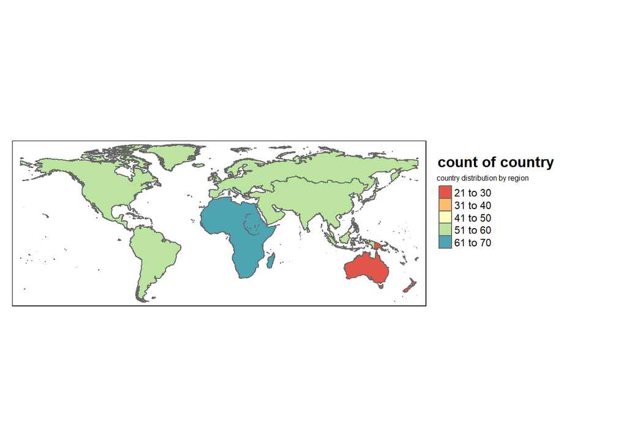

The distribution of countries as a region is as shown in the graph. The African and Asian continents make up the majority of the countries. While earthquakes are mostly observed in Africa and Asia, Tsunami, mountain explosion and earthquake are observed in Oceania. There are earthquakes, hurricanes, floods, erosion, rock glaciers in Europe. Hurricanes, earthquakes and tsunamis are in the foreground in America. The common disaster in every continent is the earthquake.There is also a pandemic.

In our data, the risk rate is examined in 5 categories as very low, low, medium, high and very high. The risk ratio, which is our main data, is calculated as
$$Risk = HazardExposure\frac{1}{3}* Vulnerability*\frac{1}{3}*Lack of coping capacity*\frac{1}{3}$$
as mentioned before. * Exposure to earthquakes, storms, floods, drought, and sea-level rise * Susceptibility depending on infrastructure, food supply, and economic framework conditions * Coping capacities depending on governance, health care, social and material security * Adaptive capacities related to upcoming natural events, climate change,and other challenges.

In this report, countries with a very high overall risk level will be examined. Topics such as which disasters are more likely to occur in these countries and which disasters should countries given first priority were examined and tried to be visualized.

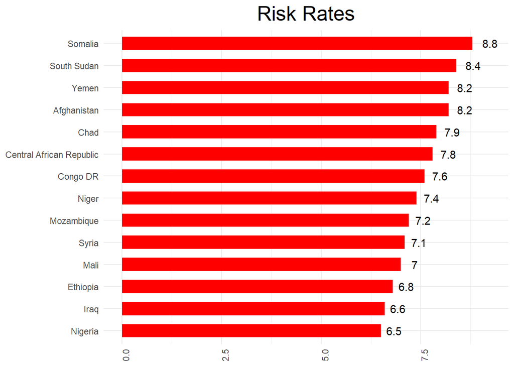

As can be seen, all of them are close to each other in terms of risk level, the lowest risk level is Nigeria with 6.5, while the country with the highest risk rate is Somalia with 8.8. Upon the researches made in Somalia, it has been observed that it progresses on a scale of two rainy and two dry seasons per year. Thus, when it receives a lot of precipitation, the rate of exposure to flooding is high. Climate change is one of the biggest risks.Based on the equation of the risk data, the sub-headings that create those indicators and trigger these risks or increase the possibility of being damaged by the risks were included in the examination. In Hazard Exposure, we examine natural disasters and man-made disasters as sub-titles, Food availability Score under the main title of Vulneribility, and Drinking water and Government Effectiveness under the main title of Natural Disasters total population Lack of capacity.

These data were calculated and used in different excel files. For this reason, it is desired to make observations on country basis and examining risk ratios by combining two data files with the sqldf command.

Hazard Exposure is divided into Natural and Human and thus this ratio was calculated. For better understanding, these two subgroups were visualized. In addition, the probability of being affected by the disaster was tried to be explained by thinking that it could be the population level. It started with the population first, because the population ratio in the country is visualized to estimate the number of people affected by disasters, or to observe how much the man-made disaster rate is in places where the human population is high.

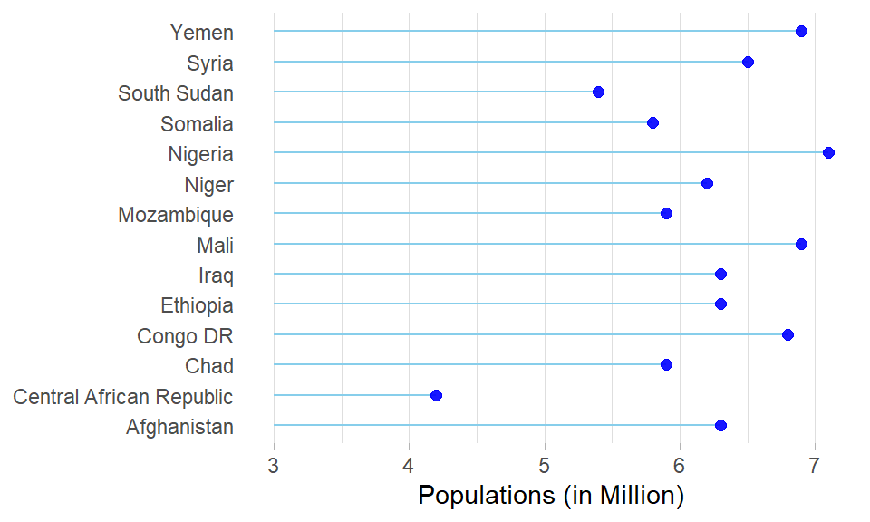

As can be seen from the chart, Nigeria (risk ratio 6.5) has the highest population, while the Central African Republic (risk ratio 7.8) has the lowest. When looking at natural disasters, it is thought that while human disasters are more in certain countries, natural disasters are less and vice versa, these rates may vary according to the population or many social-economic conditions may be effective. For example, human disasters are high in Afghanistan, Syria, Yemen and Somalia. Considering the population ratio of this country, Yemen has the highest population among them. Others are average values.

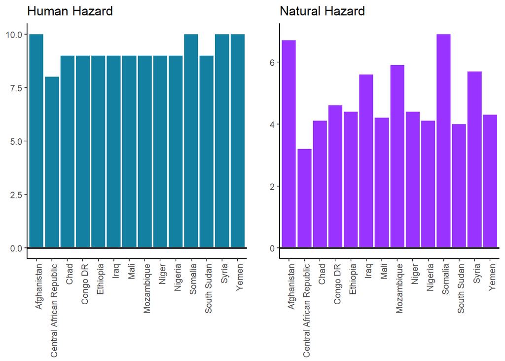

When the hazard Exposure calculated with other indicators in our main data is considered, it has been observed that some of them increased at the same rate as man-made disasters, or even more, and some decreased. The countries with the highest Natural Hazard rate are Afghanistan and Somalia, as we mentioned at the beginning, somalia is already a country affected by floods due to climate crises, when Afghanistan is investigated, it is possible to see that it is faced with disasters such as earthquakes and landslides.

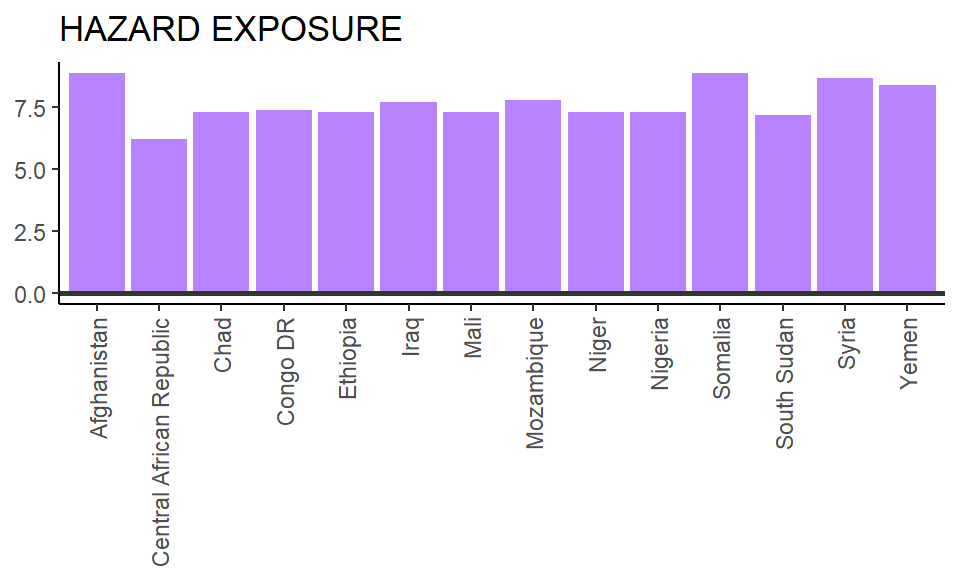

When Hazard exposure, which is the main topic, is examined, it has been observed that this ratio of countries with large natural and man-made disasters is also large, and at the same time it has been observed that the risk ratio is at the same level.

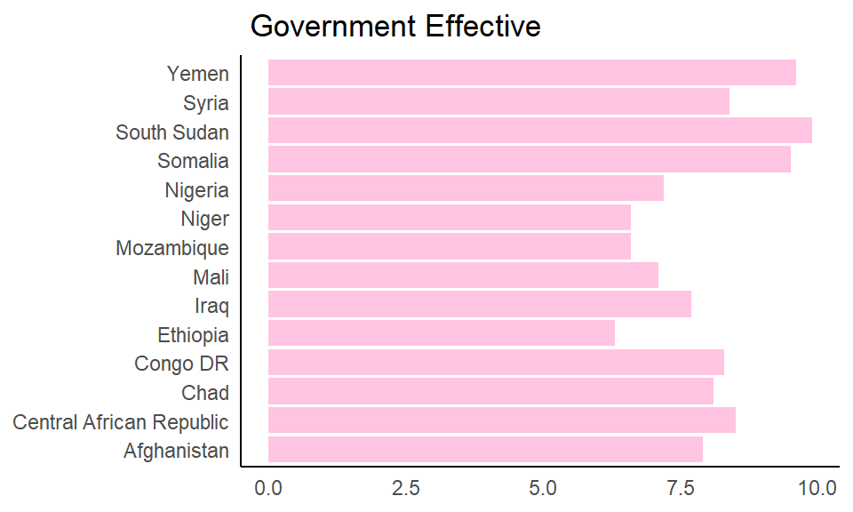

The moment of disaster is a moment of crisis and it is very important how the countries, that is, the states, can manage this moment and cope with it. This role is very important in terms of getting rid of the disaster with the least damage (material - moral). It has been tried to visualize the effective rates of states in terms of disaster preparedness policies or capacity preparation. When we look at the four countries affected by the disasters mentioned in the chart above, it is seen that the Yemeni state is effective, the Somalia state is effective, the Afghanistan state is moderately, the Syrian state is moderately effective but higher than the Afghanistan state.

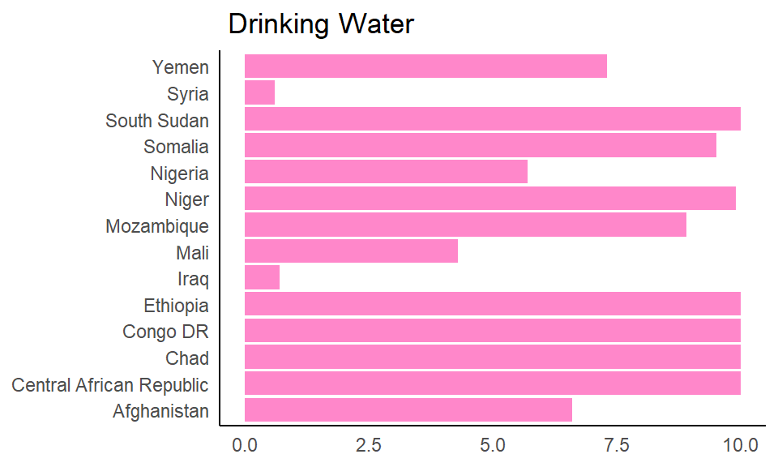

Water is the most important source of life for humanity. Emotions such as panic, excitement, fear experienced at the time of a disaster increase the need for water, or the need for reproduction of many products (areas such as fields) are affected. Or the scarcity of water in the first place creates a human-based disaster. The decrease in the amount of water per capita can cause panic in people, while it can lead to fights, turmoil and man-made disasters. Therefore, the water ratios of countries with high risk levels were examined. The scarcity of water in Syria and Iraq is at a remarkable rate. Since Syria is a country open to risks based on our previous studies, scarcity of water can lead to many negative situations. In the measures that can be taken, the state should play an effective role and develop a solution to water scarcity.

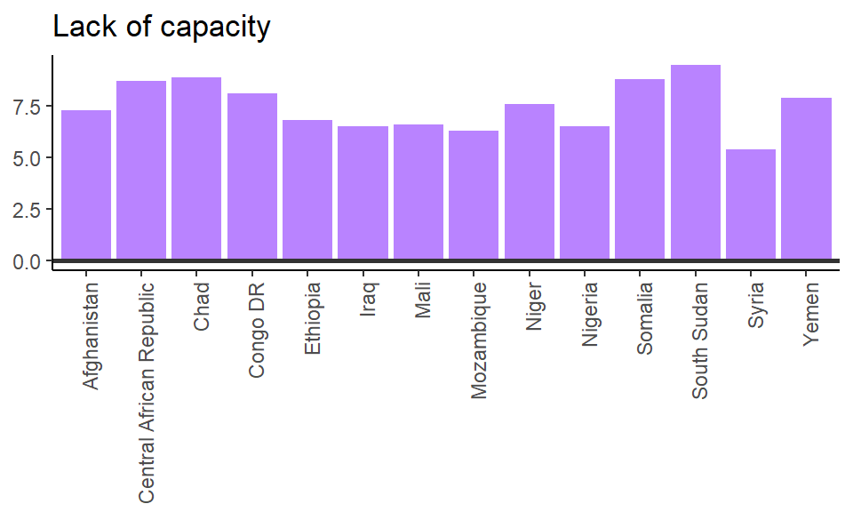

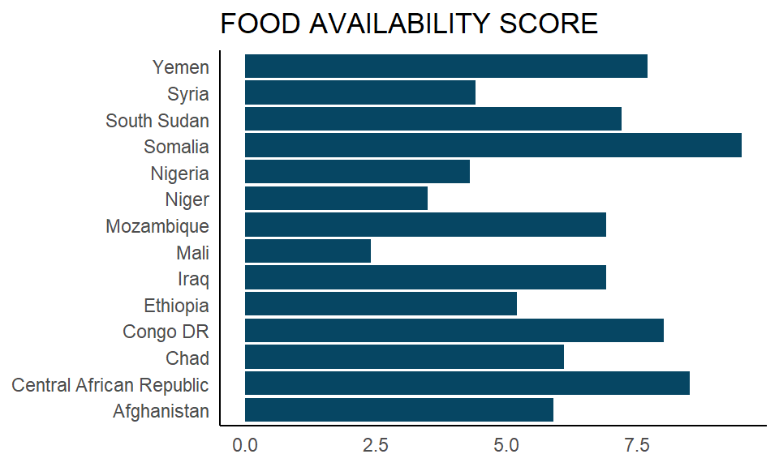

In addition to the lack of water, another important source of life for humans is the availability of food. It is seen that Mali has a shortage of food resources and the country with the most food is Somalia. The fact that events such as hunger and famine in Africa have been on the agenda for years is an event that should be evaluated in terms of the whole world.

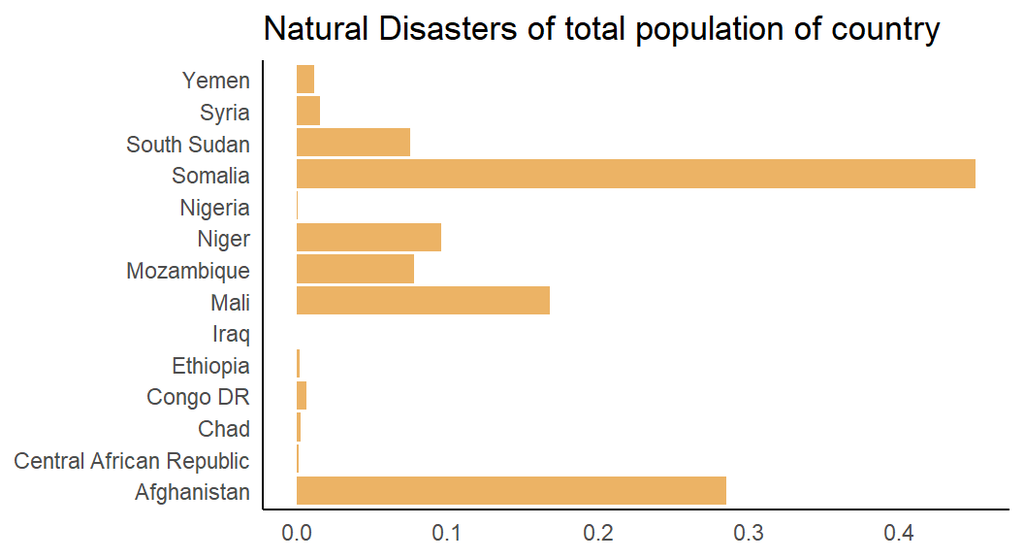

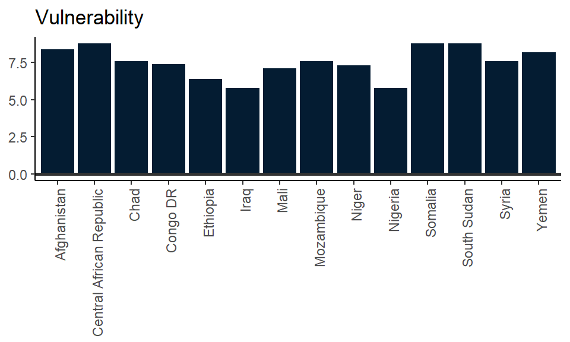

When the main topic of the food availability score and natural disaster of total population is vulnerability, it is understood that the countries are competent in this subject. It is observed that only three countries are low but balanced when compared to other indicators.

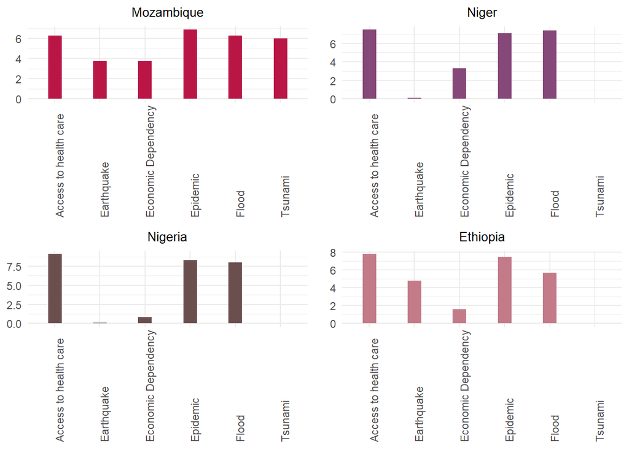

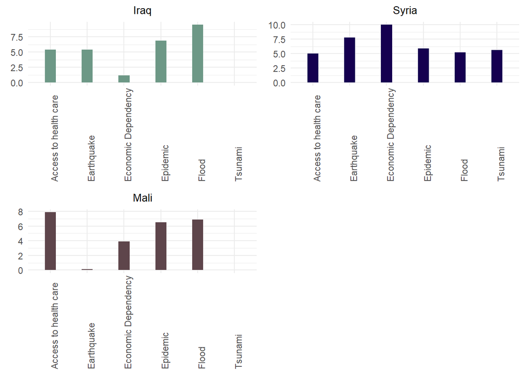